# Coursework Report

*N* removed NAs: 2

*N* removed typo: 1

*N* removed <18: 28

*N* total clean: 119

| Group | *N* | *M*<sub>age</sub> | *M*<sub>rating</sub> |
| --- | --- | --- | --- |
| Control | 58 | 20.97 | 6.30 |
| Experim | 61 | 20.39 | 7.18 |

**Main analysis results**

*t*(117) = -6.68, *p* < .001

[interactive chart not shown]

[figure not shown]

[interactive chart not shown]

# Coursework Report

Analysing Data, Spring 2020

# Methods

## Participants

Table 1 *Descriptive statistics by Condition*

| Condition | *N* | % | *M*<sub>age</sub> | *SD*<sub>age</sub> |
| --- | --- | --- | --- | --- |
| Control | 58 | 48.74 | 20.97 | 2.08 |
| Experimental | 61 | 51.26 | 20.39 | 1.87 |

## Design

The research question at hand aimed to see if colour influences attractiveness. In order to investigate this, an independant measures design was implemented.

The independant categorical variables contained two levels: a white frame (control condition) and a red frame (experimental condition). Thus, the predictor here was colour, which was manipulated in order to see the effect on the outcome - attractiveness. Attractiveness was a continous variable, listed on a scale from 1 (least attractive) to 9 (most attractive).

Thus, the following analysis tested to see if viewing a different colour frame around an image of a moderately attractive man would influence the mean ratings of his attractiveness. This was tested using a t-test, used to determine if there is a significant difference between the means of two groups.

# Results

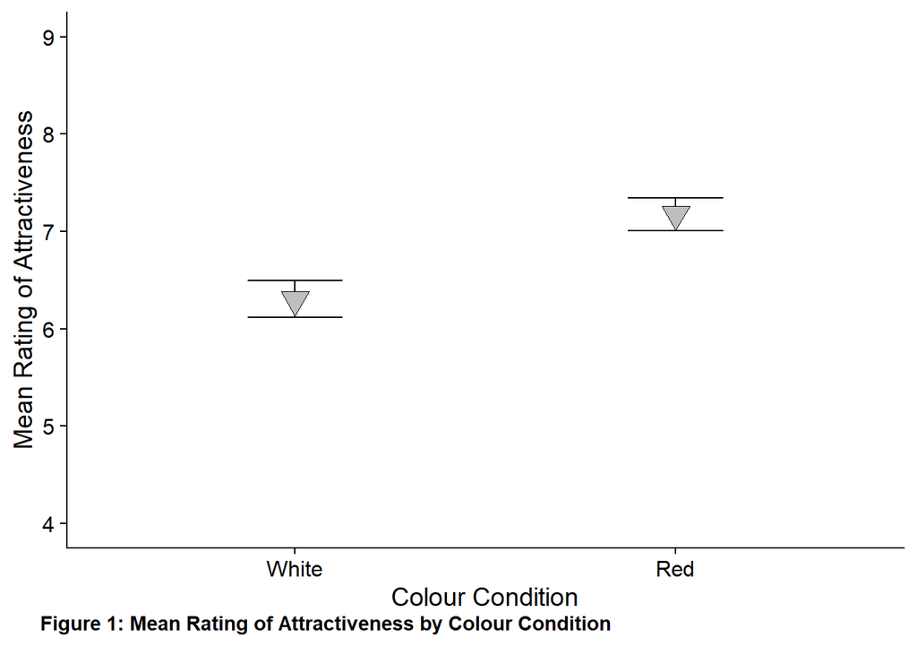

An independent-measures *t*-test was used in order to investigate whether people would rate attractiveness differently depending on colour condition, as was predicted. This test confirmed that there was a significant difference between the mean attractiveness ratings for the red vs. white colour groups (*M*<sub>diff</sub> = -0.88, 95% CI [-1.14, -0.62], *t* (117) = -6.68, *p* = .0000000).

This means that the difference between the sample means of 0.88 was 6.68 times larger than the standard error of the difference in means. That value is unlikely to occur if the true difference in means is 0 (p < 0.01). Thus, this means that it is unlikely that the two sample means are from the same population. In essence, it may be possible to reject the null hypothesis in favour of the alternative hypothesis. If this is the case, it is possible to say that colour did make a difference to attraction.

# Discussion

Overall, this research provides strong support for the hypothesis that colour would influence ratings of attractiveness: the female participants who viewed the male in the presence of a red frame rated him as being more attractive than those who viewed the male in the presence of a white frame. Thus, these findings are in line with the original research outlining this effect (Elliot et al., 2010).

However, it is important to note that although the present research provides support for the red effect, it is unable to comment on the mechanism through which Elliot et al. (2010) proposed it acts. More specifically, unlike the original study, this replication fails to consider the role of status which is said to drive this effect. As a result, this research is unable to comment on what factors may or may not underlie the development of attraction in response to the colour red. The strength of this research instead lies in its ability to demonstrate the reliability of the actual red effect in and of itself, as evidenced by the successful replication.

This is only one replication though and, in order to gain a more complete understanding of these results, it is necessary to place them within the wider context of other replications. For example, it is true that not every replication of the original study has been as successful in reproducing the red effect: Peperkoorn et al. (2016) created three different replication attempts and each one failed to demonstrate the effect. The varying levels of support for the red effect across replications begets the question why.

One possible reason was that Peperkoorn’s replication looked more specifically at sexual attraction. This contrasts the overall perception of attractiveness that was looked at in both the current replication and, in part, the original research. Sexual attraction may differ from overall attraction due to the more important role it plays in reproduction and survival (Little et al., 2007; Sardell et al., 2014). For example, it is true that people can perceive someone as attractive without personally being attracted to them (Elliot & Niesta, 2008). This differentiation between the two types was also identified in the original research (Elliot et al., 2010). If this is the case, it may be that the section of the original study concerning the perception of attractiveness better supports the red effect than the section that concerns sexual attraction; this would explain the difference between the replications.

In order to gain a full understanding of this, further research is needed. This would involve looking at the differences between sexual attraction and overall perceptions of attractiveness, as well as how they might negotiate the red effect differently. If it was found that they do create a difference in the red effect, then it would also be advisable to investigate why this is.

In conclusion, these results support the existence of the red effect wherein the colour red increases female perceptions of male attractiveness. However, contrasting replication results create a sense of confusion about the strength of this relationship. In order to solidify this understanding, further research is needed into the two different types of attraction and how they might influence this effect.

# References

Elliot, A. J., & Niesta, D. (2008). Romantic red: Red enhances men’s attraction to women. Journal of Personality and Social Psychology, 95(5), 1150–1164. https://doi.org/10.1037/0022-3514.95.5.1150

Elliot, A. J., Niesta Kayser, D., Greitemeyer, T., Lichtenfeld, S., Gramzow, R. H., Maier, M. A., & Liu, H. (2010). Red, rank, and romance in women viewing men. Journal of Experimental Psychology: General, 139(3), 399–417. http://dx.doi.org/10.1037/a0019689

Little, A. C., Jones, B. C., & Burriss, R. P. (2007). Preferences for masculinity in male bodies change across the menstrual cycle. Hormones and Behavior, 51(5), 633–639. https://doi.org/10.1016/j.yhbeh.2007.03.006

Peperkoorn, L. S., Roberts, S. C., & Pollet, T. V. (2016). Revisiting the Red Effect on Attractiveness and Sexual Receptivity: No Effect of the Color Red on Human Mate Preferences. Evolutionary Psychology, 14(4), 1474704916673841. https://doi.org/10.1177/1474704916673841

Sardell, R. J., Kempenaers, B., & Duval, E. H. (2014). Female mating preferences and offspring survival: Testing hypotheses on the genetic basis of mate choice in a wild lekking bird. Molecular Ecology, 23(4), 933–946. https://doi.org/10.1111/mec.12652